# Projet R | Paris Wi-Fi - Utilisation des hotspots du réseau

Orlane, Pablo et Tom

2022-01-10

# Préparation du script

## Packages & librairies

Installation et import des différentes librairies nécessaires au fonctionnement du script.

```r
#install.packages("remotes")
#install.packages(remotes)
#library(remotes)
#remotes::install_github("davidsjoberg/ggsankey") # Package externe, il faut aller le chercher dans une répertoire GitHub à la main.
```

```r
library(rmarkdown)
library(tidyverse)
```

```r
library(cartography)
library(ggplot2)
library(cowplot)
library(treemapify)
library(RColorBrewer)
library(sf)
library(geojsonsf)
library(ggsankey)
```

## Import des données

Données de **Paris Wi-Fi - Utilisation des hotspots du réseau**, issues de Paris | Data.

```r
wifi <- geojsonsf::geojson_sf('paris-wi-fi-utilisation-des-hotspots-paris-wi-fi.geojson')
```

**1855717** lignes et **25** colonnes importées.

Données des **Contours… IRIS**, issues de l’[IGN](https://geoservices.ign.fr/contoursiris).

```r
IRIS <- st_read("CONTOURS-IRIS.shp", stringsAsFactors = FALSE)
```

**48589** lignes et **7** colonnes importées.

# Préparation des données et représentations

## Reprojection et corrections des données de **Paris Wi-Fi - Utilisation des hotspots du réseau**

```r
wifi <- st_transform(wifi, 2154)

wifi <- wifi %>% mutate(userlanguage = case_when(userlanguage == "Chinois simplifiÃ©" | userlanguage == "Chinois simplifiâ€š" ~ "Chinois simplifié",
                                                                   userlanguage == "FranÃ§ais" | userlanguage == "Franâ€¡ais" ~ "Français",
                                                                   userlanguage == "CorÃ©en" | userlanguage == "Corâ€šen" ~ "Coréen",
                                                                   userlanguage == "IndonÃ©sien" | userlanguage == "Indonâ€šsien" ~ "Indonésien",
                                                                   userlanguage == "ThaÃ¯landais" | userlanguage == "Thaâ€¹landais" ~ "Thaïlandais",
                                                                   userlanguage == "NÃ©erlandais" | userlanguage == "Nâ€šerlandais" ~ "Néerlandais",
                                                                   userlanguage == "#N/A" ~ NA_character_,
                                                                   TRUE ~ as.character(userlanguage)),
                                code_site = case_when(code_site == "'PW0125" ~ "PW0125",
                                                       TRUE ~ code_site),
                                code_site = na_if(code_site, "#N/A"))
```

## Sélection des IRIS parisiens

```r
IRIS <- IRIS %>% filter(grepl("^75", INSEE_COM))
```

## Graphiques

### Sript pour la préparation du graphique *Vue des sessions par jour de la semaine*.

```r
#Tranformation en simple dataframe pour éviter d'alourdir les calculs.
wifidataframe <- as.data.frame(wifi)

#Ajout d'un champ dans un format date.
wifidataframe$date <- as.Date(wifidataframe$datetime)

#Aggrégation du nombre de sessions, de la durée moyenne des sessions et des données échangées par date.
graph_01 <- wifidataframe %>% select(date, duration, donnee_sortante_gigaoctet, donnee_entrante_go) %>%
  group_by(date) %>%
  summarise(NbSessions = n(),
            duree_session_minutes = mean(duration / 60),
            donnees_sortante_GO = mean(donnee_sortante_gigaoctet),
            donnees_entrante_GO = mean(donnee_entrante_go))

#Ajout d'un champ contenant le jour de la semaine.
graph_01$jour <- weekdays.Date(graph_01$date)

#Aggrégation du nombre de sessions, de la durée moyenne des sessions et des données échangées par jour de la semaine.
graph_1 <- graph_01 %>% select(jour, NbSessions, duree_session_minutes, donnees_sortante_GO, donnees_entrante_GO) %>%
  group_by(jour) %>%
  summarise(NbSessions = mean(NbSessions),
            duree_session_minutes = mean(duree_session_minutes),
            donnees_sortante_GO = mean(donnees_sortante_GO),
            donnees_entrante_GO = mean(donnees_entrante_GO))

#Tri selon les jours de la semaine.
graph_1$jour <- ordered(graph_1$jour, levels=c("lundi", "mardi", "mercredi", "jeudi",
                                             "vendredi", "samedi", "dimanche"))

graph_1 <- graph_1 %>% arrange(jour)

head(graph_1)
```

```
#> # A tibble: 6 x 5
#>   jour     NbSessions duree_session_minutes donnees_sortante_GO donnees_entrant~
#>   <ord>         <dbl>                 <dbl>               <dbl>            <dbl>
#> 1 lundi         1682.                  33.8                8.43             56.0
#> 2 mardi         2577.                  39.8                9.83             64.6
#> 3 mercredi      2876.                  39.5                9.76             63.5
#> 4 jeudi         2592.                  39.3                9.35             64.3
#> 5 vendredi      2590.                  38.5                9.33             64.0
#> 6 samedi        2517.                  38.5                9.33             64.9
```

Jour ayant le temps de session moyen le plus important (**39.83** minutes) : **mardi**

Jour ayant la quantité moyenne de données téléchargées la plus importante (**64.89** GO) : **samedi**.

### Datavisualisation de la *Vue des sessions par jour de la semaine*

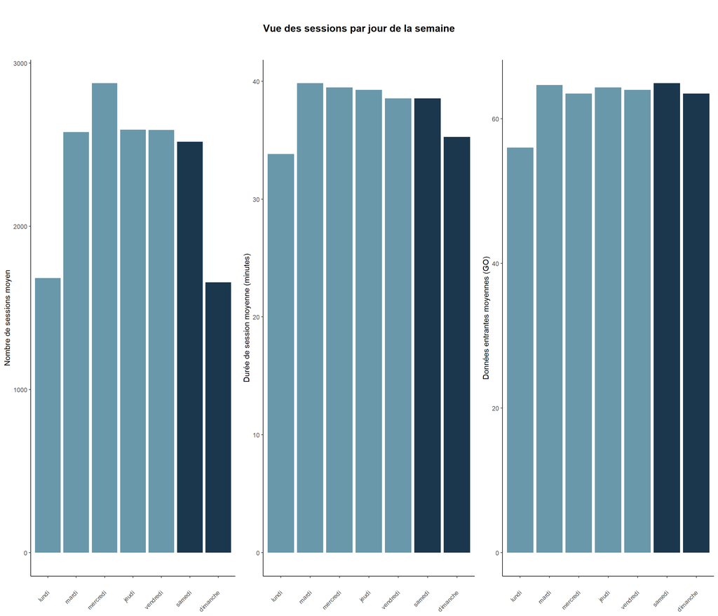

```r
# Premier partie du premier small multiple
# Nombre de sessions par jour
graph_1.1 <- ggplot(graph_1, aes(x=jour, y=NbSessions, fill=jour)) +
  geom_bar(stat="identity", show.legend = FALSE) +
  theme_classic() +
  theme(axis.text.x = element_text(angle = 45, vjust = 0.5, hjust=1)) +
  scale_fill_manual(values=c("#6998AB", "#6998AB", "#6998AB", "#6998AB", "#6998AB", "#1A374D", "#1A374D"))+
  labs(x ="" , y = "Nombre de sessions moyen")

# Deuxième partie du premier small multiples
# Duration moyenne des sessions
graph_1.2 <- ggplot(graph_1, aes(x=jour, y=duree_session_minutes, fill=jour)) +
  geom_bar(stat="identity", show.legend = FALSE) +
  theme_classic() +
  theme(axis.text.x = element_text(angle = 45, vjust = 0.5, hjust=1)) +
  scale_fill_manual(values=c("#6998AB", "#6998AB", "#6998AB", "#6998AB", "#6998AB", "#1A374D", "#1A374D"))+
  labs(x ="" , y = "Durée de session moyenne (minutes)")

# Troisième partie du premier small multiple
# Moyenne des données téléchargées
graph_1.3 <- ggplot(graph_1, aes(x=jour, y=donnees_entrante_GO, fill=jour)) +
  geom_bar(stat="identity", show.legend = FALSE) +
  theme_classic() +
  theme(axis.text.x = element_text(angle = 45, vjust = 0.5, hjust=1)) +
  scale_fill_manual(values=c("#6998AB", "#6998AB", "#6998AB", "#6998AB", "#6998AB", "#1A374D", "#1A374D"))+
  labs(x ="" , y = "Données entrantes moyennes (GO)")

# Regroupement des 3 parties du premier small multiple
p <- plot_grid(graph_1.1, graph_1.2, graph_1.3,
               nrow=1, ncol=3) # , labels=c('A', 'B', 'C')  -> Pour labelliser si nécessaire


# Titre du premiere small multiple
title_graph1 <- ggdraw() + draw_label("Vue des sessions par jour de la semaine", fontface='bold')

#Print du graphique
plot_grid(title_graph1, p, ncol=1, rel_heights=c(0.1, 1))
```

### Script pour la préparation du graphique *Utilisateurs étrangers principaux*.

```r
#Aggrégation du nombre de sessions par language utilisateur et création d'un champ pourcentage.
graph_2 <- wifidataframe %>% select(userlanguage) %>%
  group_by(userlanguage) %>%
  summarise(NbSessions = n()) %>%
  mutate(Pourcentage = round((NbSessions/sum(NbSessions)*100), 2)) %>%
  arrange(desc(Pourcentage)) %>%
  mutate(Pourcentage_str = str_c(Pourcentage, '%'))

head(graph_2)
```

```
#> # A tibble: 6 x 4
#>   userlanguage NbSessions Pourcentage Pourcentage_str
#>   <chr>             <int>       <dbl> <chr>
#> 1 Français        1377269       74.2  74.22%
#> 2 Anglais          252193       13.6  13.59%
#> 3 <NA>              60024        3.23 3.23%
#> 4 Espagnol          39388        2.12 2.12%
#> 5 Russe             29279        1.58 1.58%
#> 6 Allemand          21644        1.17 1.17%
```

### Datavisualisation des *Utilisateurs étrangers principaux*

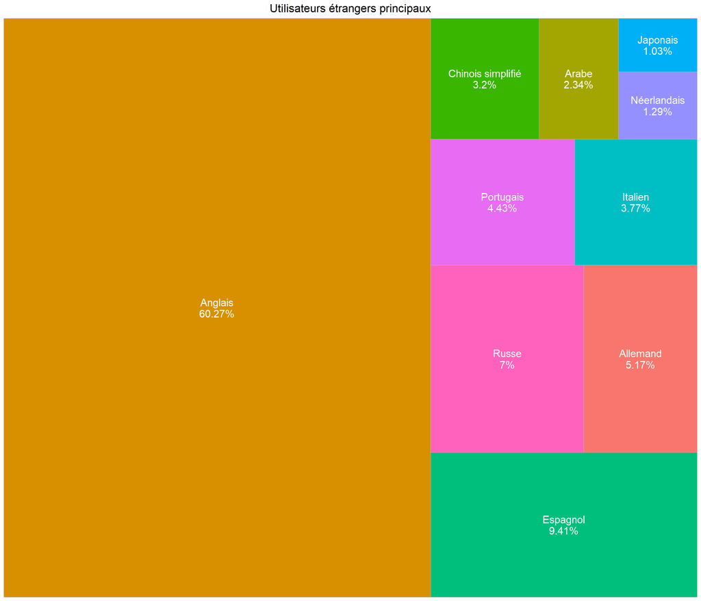

```r
#Filtre des utilisateurs français et aggrégation du nombre de sessions par language utilisateur et création d'un champ pourcentage.
graph_2.1 <- graph_2 %>% filter(userlanguage != "Français") %>%
  mutate(Pourcentage = round((NbSessions/sum(NbSessions)*100), 2)) %>%
  filter(Pourcentage > 1) %>%
  arrange(desc(Pourcentage)) %>%
  mutate(Pourcentage_str = str_c(Pourcentage, '%'))

ggplot(graph_2.1, aes(area=NbSessions, fill=userlanguage, label = paste(userlanguage, Pourcentage_str, sep = "\n"))) +
  geom_treemap() +
  geom_treemap_text(colour = "white",
                    place = "centre",
                    size = 15) +
  theme(legend.title=element_blank(), plot.title = element_text(hjust = 0.5, size = 16), legend.position = "none") +
  ggtitle("Utilisateurs étrangers principaux")
```

### Script pour la préparation du graphique *Comparaison de la consommation de données et du temps de session par langue*

```r
#Aggrégation de la durée de session moyenne et des données échangées moyenne par langue utilisateur.
graph_3 <- wifidataframe %>% select(userlanguage, duration, donnee_sortante_gigaoctet, donnee_entrante_go) %>%
  group_by(userlanguage) %>%
  summarise(duree_session_minutes = mean(duration / 60),
            donnees_sortante_GO = mean(donnee_sortante_gigaoctet),
            donnees_entrante_GO = mean(donnee_entrante_go)) %>%
  drop_na() %>%
  arrange(duree_session_minutes) %>%
  mutate(userlanguage = factor(userlanguage, levels = userlanguage))

head(graph_3)
```

```
#> # A tibble: 6 x 4
#>   userlanguage duree_session_minutes donnees_sortante_GO donnees_entrante_GO
#>   <fct>                        <dbl>               <dbl>               <dbl>
#> 1 Portugais                     23.3               10.4                 26.8
#> 2 Espagnol                      25.1                9.05                33.1
#> 3 Néerlandais                   26.0               10.1                 32.2
#> 4 Indonésien                    29.5                4.91                31.2
#> 5 Allemand                      29.9                9.52                41.4
#> 6 Japonais                      31.0               10.5                 38.2
```

Les plus gros consommateurs de données sont les utilisateurs avec la langue **Arabe** configurée. En moyenne par session, ils consomment **91.23** GO de données.

Les utilisateurs les plus longtemps connectés sont les utilisateurs avec la langue **Chinois traditionnel** configurée. En moyenne par session, ils restent connectés **58.7** minutes.

### Datavisualisation de la *Comparaison de la consommation de données et du temps de session par langue*

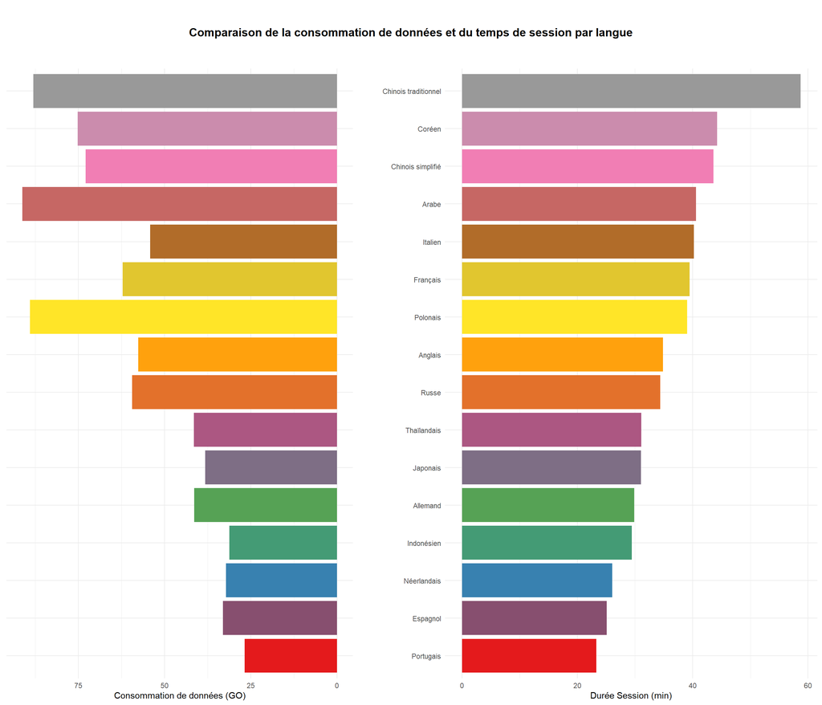

```r
colourCount <- nrow(graph_3)
getPalette <- colorRampPalette(brewer.pal(9, "Set1"))

# Premiere partie du deuxième small multiple
# Duree Session en minutes par langue
graph_3.1 <- ggplot(graph_3, aes(x=userlanguage, y=duree_session_minutes, fill=userlanguage)) +
  geom_bar(stat="identity", show.legend = FALSE, fill=getPalette(colourCount)) +
  theme_minimal() +
  theme(axis.title.y = element_text(size=8, margin = margin(r = 18)))+
  background_grid(FALSE) +
  labs(x ="" , y = "Durée Session (min)") +
  coord_flip()

# Deuxième partie du deuxième small multiple
# Consommation de données en GO par langue
graph_3.2 <- ggplot(graph_3, aes(x=userlanguage, y=donnees_entrante_GO, fill=userlanguage)) +
  geom_bar(stat="identity", show.legend = FALSE, fill=getPalette(colourCount)) +
  theme_minimal() +
  theme(axis.title.y=element_blank(),
        axis.text.y = element_blank()) +
  background_grid(FALSE) +
  labs(x ="" , y = "Consommation de données (GO)") +
  coord_flip() + scale_y_reverse()

# Regroupement des 2 parties du deuxième small multiple
p3 <- plot_grid(graph_3.2, graph_3.1,
                nrow=1, ncol=2, rel_widths = c(1,1.3))

# Titre du deuxième small multiple
title_graph3 <- ggdraw() + draw_label("Comparaison de la consommation de données et du temps de session par langue", fontface='bold')

# Print du deuxième small multiple
plot_grid(title_graph3, p3, ncol=1, rel_heights=c(0.1, 1))
```

### Script pour la préparation du graphique *Sankey*

```r
#Reclassification des systèmes d'exploitations et de la consommation de données.
graph_4 <- wifidataframe %>% select(Systeme = device_operating_system_name_version,
                                           Appareil = device_portal_format,
                                           Donnees = donnee_entrante_go) %>%
  mutate(Donnees = as.integer(Donnees*1000)) %>%
  mutate(Systeme = case_when(startsWith(Systeme,"An") ~ "Android",
                        startsWith(Systeme,"iOS") ~ "iOS",
                        startsWith(Systeme,"Mac") ~ "Mac",
                        startsWith(Systeme,"PlayStation Vita") ~ "Playstation Vita",
                        startsWith(Systeme,"Windows Phone") ~ "Windows Phone",
                        Systeme=="Windows 10" | Systeme=="Windows 7" | Systeme=="Windows 8" | Systeme=="Windows Vista" | Systeme=="Windows XP" ~ "Windows",
                        Systeme=="inconnu" | Systeme=="unknown" | is.na(Systeme) ~ "Inconnu",
                        Systeme=="Linux unknown"~"Linux",
                        TRUE ~ as.character(Systeme))) %>%
  mutate(Donnees = case_when(Donnees <1~"<1 MO",
                             Donnees >=1 & Donnees <500 ~"1-500 MO",
                             Donnees >=500 & Donnees <1000~"0,5-1 GO",
                             Donnees >=1000 & Donnees <10000~"1-10 GO",
                             Donnees >=10000 & Donnees <50000~"10-50 GO",
                             Donnees >=50000 & Donnees <=100000~"50-100 GO",
                             Donnees >100000~">100 GO",
                             TRUE ~ as.character(Donnees))) %>%
  make_long(Systeme, Appareil, Donnees) # D'une table large à longue

head(graph_4)
```

```
#> # A tibble: 6 x 4
#>   x        node     next_x   next_node
#>   <fct>    <chr>    <fct>    <chr>
#> 1 Systeme  iOS      Appareil Mobile
#> 2 Appareil Mobile   Donnees  1-10 GO
#> 3 Donnees  1-10 GO  <NA>     <NA>
#> 4 Systeme  Android  Appareil Mobile
#> 5 Appareil Mobile   Donnees  10-50 GO
#> 6 Donnees  10-50 GO <NA>     <NA>
```

### Datavisualisation du *Sankey*

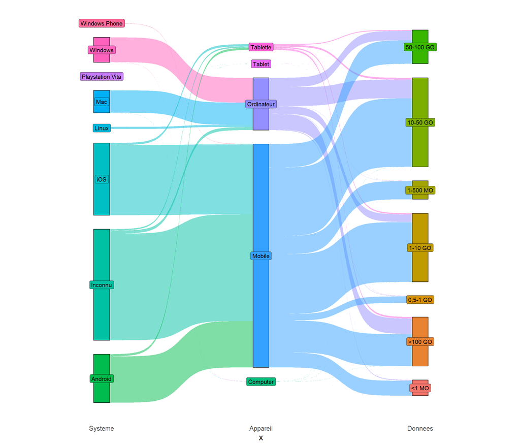

```r
#Print Sankey
ggplot(graph_4, aes(x = x,
                    next_x = next_x,
                    node = node,
                    next_node = next_node,
                    fill = factor(node),
                    label = node))+
  geom_sankey(flow.alpha=0.5,
              node.color="Black",
              show.legend = FALSE) +
  geom_sankey_label(size = 4)+
  theme_sankey(base_size = 16, base_line_size = 100)+
  theme(legend.position = "none")
```

### Script pour la préparation du graphique du *Nombre de sessions par type d’appareil des 10 principaux hotspots*

```r
#Reclassification des types d'appareils.
wifidataframe <- wifidataframe %>% mutate(device_portal_format = case_when(device_portal_format == "Computer" ~ "Ordinateur",
                                                                           device_portal_format == "Tablet" ~ "Tablette",
                                                                           TRUE ~ as.character(device_portal_format)))

#Aggrégation du nombre de sessions par nom de hotspot et sélection des 10 plus importants.
graph_05 <- wifidataframe %>% group_by(nom_site) %>%
  summarise(NbSessions = n()) %>%
  arrange(desc(NbSessions)) %>%
  slice(1:10)

#Aggrégation du nombre de sessions par nom de hotspot et par type d'appareil et filtre sur les 10 hotspots les plus importants.
graph_5 <- wifidataframe %>% group_by(nom_site, device_portal_format) %>%
  summarise(NbSessions = n()) %>%
  filter(nom_site %in% graph_05$nom_site)
#Tri selon les hotspots les plus importants.
graph_5$nom_site <- ordered(graph_5$nom_site, levels=c("BIBLIOTHEQUE MARGUERITE DURAS", "MEDIATHEQUE FRANCOISE SAGAN", "JARDIN DU TROCADERO",
                                                       "JARDIN NELSON MANDELA", "BIBLIOTHEQUE MARGUERITE YOURCENAR", "BIBLIOTHEQUE EDMOND ROSTAND",
                                                       "BIBLIOTHEQUE HISTORIQUE DE LA VILLE DE PARIS (BHVP)", "PARC DE CHOISY",
                                                       "BIBLIOTHEQUE VACLAV HAVEL", "BIBLIOTHEQUE AIME CESAIRE"))

head(graph_5)
```

```
#> # A tibble: 6 x 3
#> # Groups:   nom_site [2]
#>   nom_site                    device_portal_format NbSessions
#>   <ord>                       <chr>                     <int>
#> 1 BIBLIOTHEQUE AIME CESAIRE   Mobile                    24442
#> 2 BIBLIOTHEQUE AIME CESAIRE   Ordinateur                 3781
#> 3 BIBLIOTHEQUE AIME CESAIRE   Tablette                    299
#> 4 BIBLIOTHEQUE EDMOND ROSTAND Mobile                    27422
#> 5 BIBLIOTHEQUE EDMOND ROSTAND Ordinateur                 5287
#> 6 BIBLIOTHEQUE EDMOND ROSTAND Tablette                    662
```

### Datavisualisation du graphique du *Nombre de sessions par type d’appareil des 10 principaux hotspots*

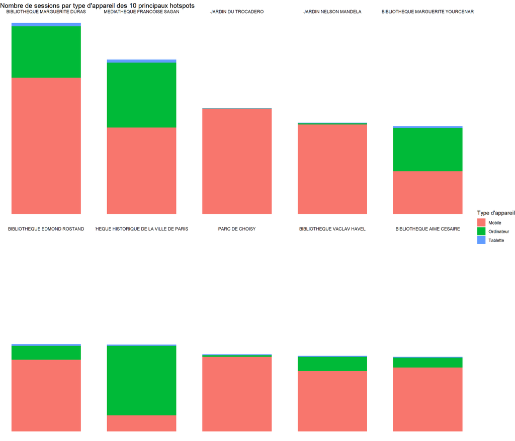

```r
ggplot(graph_5, aes(x = " ", y = NbSessions, group = nom_site, fill = device_portal_format)) +
  geom_bar(stat = "identity") +
  facet_wrap(~ nom_site, ncol = 5) +
  theme(strip.text.x = element_text(size = 6, face = "bold")) +
  guides(fill = guide_legend(title = "Type d'appareil")) +
  labs(title = "Nombre de sessions par type d'appareil des 10 principaux hotspots", x = "Hotspots", y = "Nombre de sessions")+
  theme_void()
```

### Script pour la préparation du graphique du *Nombre de sessions dans les 10 IRIS parisiens ayant le plus de sessions*

```r
#Jointure du nom de l'IRIS dans lequel se trouve la session.
graph_06 <- st_join(wifi, IRIS["NOM_IRIS"])

#Aggrégation par IRIS du nombre de sessions avec sélection des 10 IRIS ayant le plus de sessions.
graph_6 <- graph_06 %>% select(NOM_IRIS) %>%
  group_by(NOM_IRIS) %>%
  summarise(NbSessions = n()) %>%
  arrange(desc(NbSessions)) %>%
  slice(1:10)

head(graph_6)
```

```
#> Simple feature collection with 6 features and 2 fields
#> Geometry type: GEOMETRY
#> Dimension:     XY
#> Bounding box:  xmin: 647862 ymin: 6858823 xmax: 656215.7 ymax: 6864130
#> Projected CRS: RGF93 / Lambert-93
#> # A tibble: 6 x 3
#>   NOM_IRIS            NbSessions                                        geometry
#>   <chr>                    <int>                                  <GEOMETRY [m]>
#> 1 Saint-Merri 4           103769 MULTIPOINT ((652251.7 6862197), (652402 686211~
#> 2 Père Lachaise 2          73137                        POINT (656215.7 6862366)
#> 3 Les Halles 5             67089 MULTIPOINT ((652013.5 6862712), (652040.9 6862~
#> 4 Porte Saint-Denis 6      65338 MULTIPOINT ((652593.8 6864128), (652709.8 6864~
#> 5 Muette 21                40495                          POINT (647862 6862557)
#> 6 Gare 28                  38027 MULTIPOINT ((652779.8 6859162), (652914.9 6858~
```

### Datavisualisation du graphique du *Nombre de sessions dans les 10 IRIS parisiens ayant le plus de sessions*

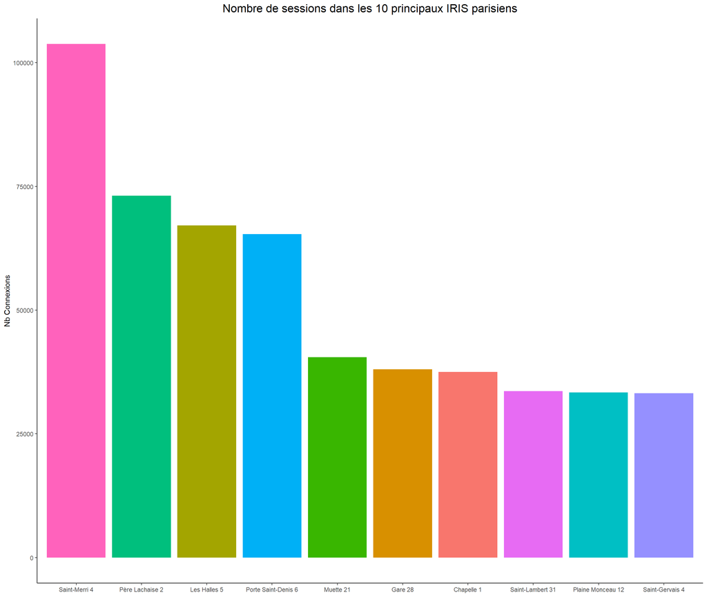

```r
ggplot(graph_6, aes(fct_reorder(as.character(NOM_IRIS), NbSessions, .desc=TRUE), NbSessions, fill=NOM_IRIS)) +
  geom_bar(stat="identity", show.legend = FALSE) +
  theme_classic() +
  ggtitle("Nombre de sessions dans les 10 principaux IRIS parisiens")+
  theme(plot.title = element_text(hjust = 0.5, size = 16))+
  labs(x ="" , y = "Nb Connexions")
```

## Cartographies

```r
#Aggrégation du nombre de bornes wifi par hotspot.
carto_01 <- wifi %>% select(code_site, nom_site, nombre_de_borne_wifi) %>%
  group_by(nom_site) %>%
  summarise(bornes_wifi = max(nombre_de_borne_wifi)) %>%
  filter(!is.na(nom_site))

#Jointure des informations du nombre de bornes wifi par hotspot aux IRIS et aggrégation du nombre de bornes et de hotspots par IRIS.
carto_1 <- IRIS %>% st_join(carto_01, left = TRUE) %>%
  group_by(CODE_IRIS, NOM_IRIS) %>%
  summarise(NbBornes = sum(bornes_wifi),
            NbHotspots = length(na.omit(nom_site)),
            Sites = toString(unique(nom_site)))
carto_1 <- carto_1 %>% mutate_if(is.numeric, ~replace(., is.na(.), 0))
```

```
#> `mutate_if()` ignored the following grouping variables:
#> Column `CODE_IRIS`
```

```r
#Création de nouveaux champs.
carto_1$SURFACE <- (st_area(carto_1) / 1000)

carto_1$HS_km2 <- carto_1$NbHotspots / carto_1$SURFACE

carto_1$B_km2 <- carto_1$NbBornes / carto_1$SURFACE

head(carto_1)
```

```
#> Simple feature collection with 6 features and 8 fields
#> Geometry type: MULTIPOLYGON
#> Dimension:     XY
#> Bounding box:  xmin: 650181.1 ymin: 6861761 xmax: 652179 ymax: 6863141
#> Projected CRS: RGF93 / Lambert-93
#> # A tibble: 6 x 9
#> # Groups:   CODE_IRIS [6]
#>   CODE_IRIS NOM_IRIS   NbBornes NbHotspots Sites                        geometry
#>   <chr>     <chr>         <dbl>      <dbl> <chr>              <MULTIPOLYGON [m]>
#> 1 751010101 Saint-Ger~        1          1 BERGES~ (((652096.5 6862110, 652081.~
#> 2 751010102 Saint-Ger~        0          0 NA      (((651932.7 6861790, 651847.~
#> 3 751010103 Saint-Ger~       20          2 PREFOU~ (((651869 6862406, 651854.7 ~
#> 4 751010104 Saint-Ger~        0          0 NA      (((651639.9 6862522, 651619.~
#> 5 751010105 Tuileries         0          0 NA      (((650370.5 6863139, 650390.~
#> 6 751010199 Seine et ~        1          1 BERGES~ (((652096.5 6862110, 652093.~
#> # ... with 3 more variables: SURFACE [m^2], HS_km2 [1/m^2], B_km2 [1/m^2]
```

IRIS ayant le plus de bornes wifi : **Saint-Gervais 1** avec **38** bornes à disposition. Ces **38** sont réparties sur **3** hotspots : **ACADEMIE DU CLIMAT, BIBLIOTHEQUE ARTHUR RIMBAUD, BIBLIOTHEQUE FORNEY**.

IRIS ayant le plus de hotspots : **Saint-Merri 4** équipés par un ensemble de **29** bornes. Ces hotspots sont : **HOTEL DE VILLE PARVIS 9, HOTEL DE VILLE 1ER, HOTEL DE VILLE 2EME, HOTEL DE VILLE 3EME, HOTEL DE VILLE 4EME, HOTEL DE VILLE PARVIS RIVOLI, HOTEL DE VILLE PARVIS SEINE, HOTEL DE VILLE RDC, HOTEL DE VILLE SOUS SOL, SQUARE DE LA TOUR SAINT JACQUES**

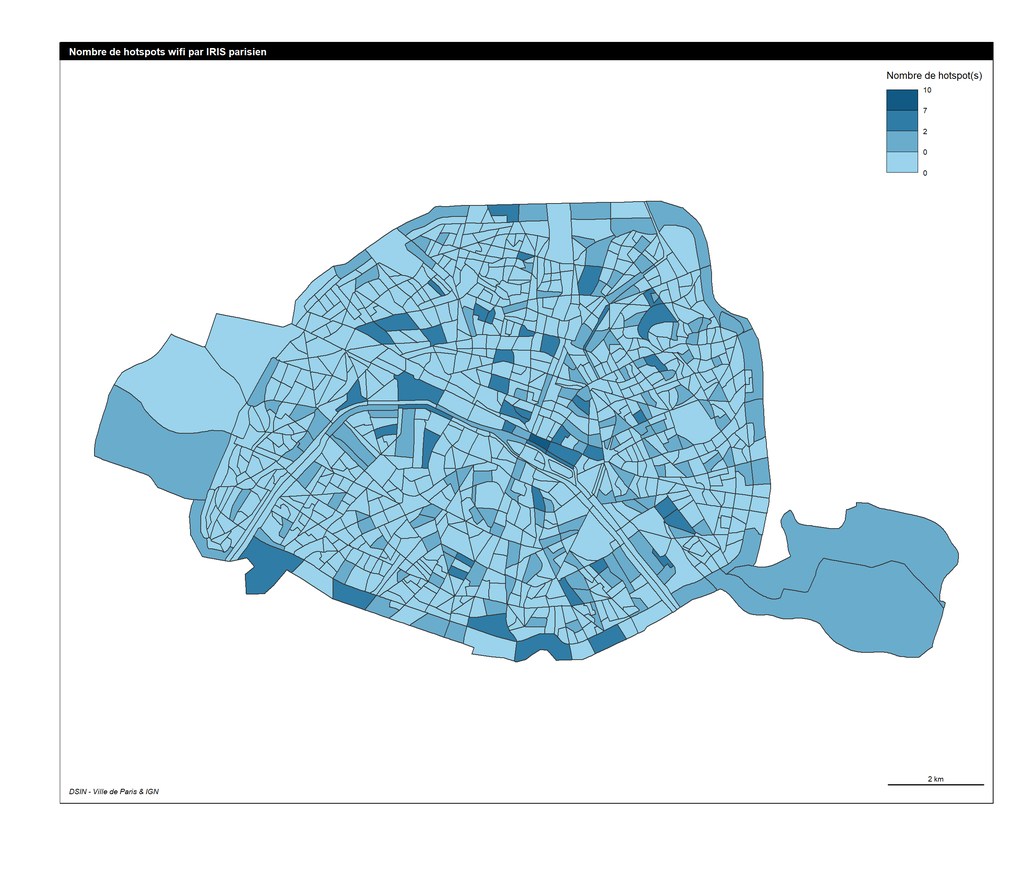

```r
choroLayer(x = carto_1,
           var = "NbHotspots",
           method = "fisher-jenks",
           nclass = 4,
           legend.title.txt = "Nombre de hotspot(s)",
           legend.pos = "topright")
layoutLayer(title = "Nombre de hotspots wifi par IRIS parisien",
            sources = "DSIN - Ville de Paris & IGN")
```

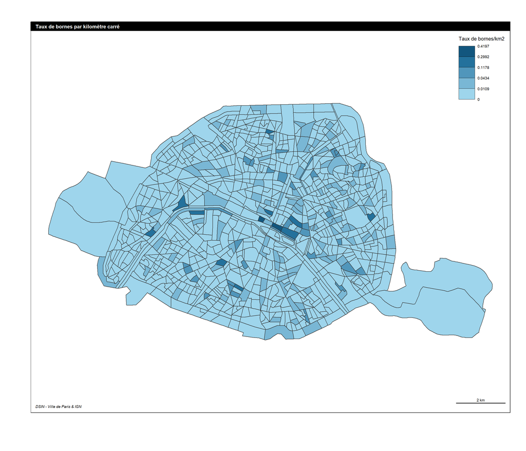

```r
choroLayer(x = carto_1,
           var = "B_km2",
           method = "fisher-jenks",
           nclass = 5,
           legend.title.txt = "Taux de bornes/km2",
           legend.pos = "topright",
           legend.values.rnd = 4)
layoutLayer(title = "Taux de bornes par kilomètre carré",
            sources = "DSIN - Ville de Paris & IGN")
```

### Script pour la préparation de la cartographie du *Nombre de bornes wifi par hotspot*

```r
#Aggrégation du nombre de bornes wifi par hotspot.
carto_2 <- wifi %>% select(code_site, nom_site, nombre_de_borne_wifi) %>%
  group_by(code_site) %>%
  summarise(bornes_wifi = max(nombre_de_borne_wifi)) %>%
  filter(!is.na(code_site))

head(carto_2)
```

```
#> Simple feature collection with 6 features and 2 fields
#> Geometry type: POINT
#> Dimension:     XY
#> Bounding box:  xmin: 650112.1 ymin: 6864201 xmax: 655126.2 ymax: 6866040
#> Projected CRS: RGF93 / Lambert-93
#> # A tibble: 6 x 3
#>   code_site bornes_wifi           geometry
#>   <chr>           <dbl>        <POINT [m]>
#> 1 PW0001              2   (654476 6866040)
#> 2 PW0002              2 (653909.8 6865378)
#> 3 PW0003              1 (650112.1 6865745)
#> 4 PW0004              1 (654757.1 6865162)
#> 5 PW0005              1 (655126.2 6864201)
#> 6 PW0006              4 (652636.8 6865132)
```

### Script pour la préparation de la datavisualisation du *Nombre de bornes wifi par hotspot*

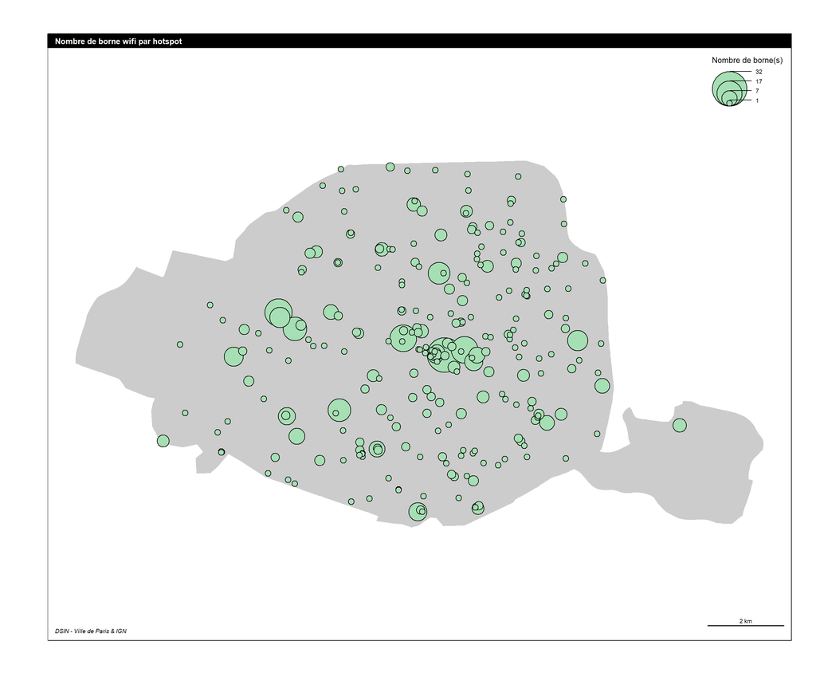

```r
plot(st_geometry(st_union(carto_1)),
     col = "grey80",
     border = "white")
propSymbolsLayer(x = carto_2,
                 var = "bornes_wifi",
                 col = "#a7dfb4",
                 legend.title.txt = "Nombre de borne(s)",
                 legend.pos = "topright"
)
layoutLayer(title = "Nombre de borne wifi par hotspot",
            sources = "DSIN - Ville de Paris & IGN")
```

### Script pour la préparation de la cartographie de *Zone de chalandise des hotspots*

```r
#Aggrégation du nombre de connexions et des temps (moyen et total) des sessions par hotspot.
carto_03 <- wifi %>%
  group_by(code_site) %>%
  summarise(NbConnexions = n(),
            Temps_moy = mean(duration / 60),
            Temps_total = sum(duration / 60)) %>%
  filter(!is.na(code_site))

#Création de polygones de Voronoï selon les hotspots.
carto_3 <- st_voronoi(x = st_union(carto_03))
carto_3 <- st_intersection(st_cast(carto_3), st_union(IRIS))
carto_3 <- st_join(x = st_sf(carto_3), y = carto_03, join=st_intersects)
carto_3 <- st_cast(carto_3, "MULTIPOLYGON")

carto_3$SURFACE <- st_area(carto_3)

head(carto_3)
```

```
#> Simple feature collection with 6 features and 5 fields
#> Geometry type: MULTIPOLYGON
#> Dimension:     XY
#> Bounding box:  xmin: 643075.6 ymin: 6858891 xmax: 647541.5 ymax: 6864071
#> Projected CRS: RGF93 / Lambert-93
#>   code_site NbConnexions Temps_moy Temps_total                       geometry
#> 1    PW0102         1232  65.17006   80289.517 MULTIPOLYGON (((643199.3 68...
#> 2    PW0108        15986  40.72655  651054.567 MULTIPOLYGON (((646047.4 68...
#> 3  PW0173-2         1604  26.79260   42975.333 MULTIPOLYGON (((646873.1 68...
#> 4    PW0202         4240  58.20996  246810.250 MULTIPOLYGON (((646362.3 68...
#> 5    PW0140          539  27.51846   14832.450 MULTIPOLYGON (((645097.6 68...
#> 6    PW0228          141  58.37648    8231.083 MULTIPOLYGON (((646099.5 68...
#>           SURFACE
#> 1 6601080.7 [m^2]
#> 2  506640.4 [m^2]
#> 3  326343.2 [m^2]
#> 4  891283.9 [m^2]
#> 5 2002290.4 [m^2]
#> 6  515549.7 [m^2]
```

### Script pour la préparation de la datavisualisation du *Zone de chalandise des hotspots*

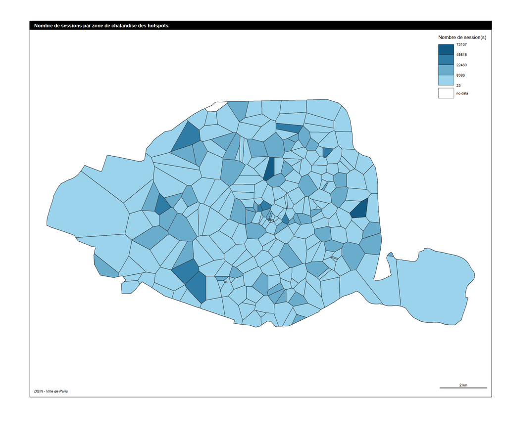

```r
choroLayer(x = carto_3,
           var = "NbConnexions",
           method = "fisher-jenks",
           nclass = 4,
           legend.title.txt = "Nombre de session(s)",
           legend.pos = "topright")
layoutLayer(title = "Nombre de sessions par zone de chalandise des hotspots",
            sources = "DSIN - Ville de Paris")
```

### Script pour la préparation de la cartographie des *Langues les plus présentes aux IRIS*

```r
#Filtre des données pour ne conserver que les utilisateurs faisant partis des 5 langues étrangères majoritaires.
carto_05 <- wifi %>% filter(userlanguage == "Anglais" | userlanguage == "Espagnol" | userlanguage == "Russe" | userlanguage == "Allemand" | userlanguage == "Portugais")

#Jointure du code IRIS aux sessions.
carto_5 <- carto_05 %>% st_join(IRIS, left = TRUE) %>% select(CODE_IRIS, userlanguage, duration)

#Création d'un objet sf pour chaque langue.
#Aggrégation du nombre de connexions et du temps moyen des sessions et jointure spatial avec les IRIS.
carto_5.anglais <- as.data.frame(carto_5) %>% select(CODE_IRIS, userlanguage, duration) %>%
  filter(userlanguage == "Anglais") %>%
  group_by(CODE_IRIS) %>%
  summarise(NbConnexions = n(),
            Temps_moy = mean(duration / 60))
  carto_5.anglais <- left_join(IRIS, carto_5.anglais, by = "CODE_IRIS") %>%
  mutate_if(is.numeric, ~replace(., is.na(.), 0))

carto_5.espagnol <- as.data.frame(carto_5) %>% select(CODE_IRIS, userlanguage, duration) %>%
  filter(userlanguage == "Espagnol") %>%
  group_by(CODE_IRIS) %>%
  summarise(NbConnexions = n(),
            Temps_moy = mean(duration / 60))
carto_5.espagnol <- left_join(IRIS, carto_5.espagnol, by = "CODE_IRIS") %>%
  mutate_if(is.numeric, ~replace(., is.na(.), 0))

carto_5.russe <- as.data.frame(carto_5) %>% select(CODE_IRIS, userlanguage, duration) %>%
  filter(userlanguage == "Russe") %>%
  group_by(CODE_IRIS) %>%
  summarise(NbConnexions = n(),
            Temps_moy = mean(duration / 60))
carto_5.russe <- left_join(IRIS, carto_5.russe, by = "CODE_IRIS") %>%
  mutate_if(is.numeric, ~replace(., is.na(.), 0))

carto_5.allemand <- as.data.frame(carto_5) %>% select(CODE_IRIS, userlanguage, duration) %>%
  filter(userlanguage == "Allemand") %>%
  group_by(CODE_IRIS) %>%
  summarise(NbConnexions = n(),
            Temps_moy = mean(duration / 60))
carto_5.allemand <- left_join(IRIS, carto_5.allemand, by = "CODE_IRIS") %>%
  mutate_if(is.numeric, ~replace(., is.na(.), 0))

carto_5.portugais <- as.data.frame(carto_5) %>% select(CODE_IRIS, userlanguage, duration) %>%
  filter(userlanguage == "Portugais") %>%
  group_by(CODE_IRIS) %>%
  summarise(NbConnexions = n(),
            Temps_moy = mean(duration / 60))
carto_5.portugais <- left_join(IRIS, carto_5.portugais, by = "CODE_IRIS") %>%
  mutate_if(is.numeric, ~replace(., is.na(.), 0))

head(carto_5.anglais)
```

```
#> Simple feature collection with 6 features and 8 fields
#> Geometry type: MULTIPOLYGON
#> Dimension:     XY
#> Bounding box:  xmin: 648979.6 ymin: 6860287 xmax: 654311.1 ymax: 6866159
#> Projected CRS: RGF93 / Lambert-93
#>   INSEE_COM                  NOM_COM IRIS CODE_IRIS                NOM_IRIS
#> 1     75111 Paris 11e Arrondissement 4113 751114113      Folie Méricourt 13
#> 2     75119 Paris 19e Arrondissement 7316 751197316             Villette 16
#> 3     75117 Paris 17e Arrondissement 6716 751176716          Batignolles 16
#> 4     75110 Paris 10e Arrondissement 3703 751103703 Saint-Vincent de Paul 3
#> 5     75106  Paris 6e Arrondissement 2201 751062201                 Odéon 1
#> 6     75118 Paris 18e Arrondissement 7104 751187104           Goutte d'Or 4
#>   TYP_IRIS NbConnexions Temps_moy                       geometry
#> 1        H          564  34.66389 MULTIPOLYGON (((654130.1 68...
#> 2        H            0   0.00000 MULTIPOLYGON (((653993.8 68...
#> 3        H            0   0.00000 MULTIPOLYGON (((649219.2 68...
#> 4        H            0   0.00000 MULTIPOLYGON (((652742.1 68...
#> 5        H          386  17.60138 MULTIPOLYGON (((651041.6 68...
#> 6        H            0   0.00000 MULTIPOLYGON (((652588.4 68...
```

### Script pour la préparation de la datavisualisation du *Langues les plus présentes aux IRIS*

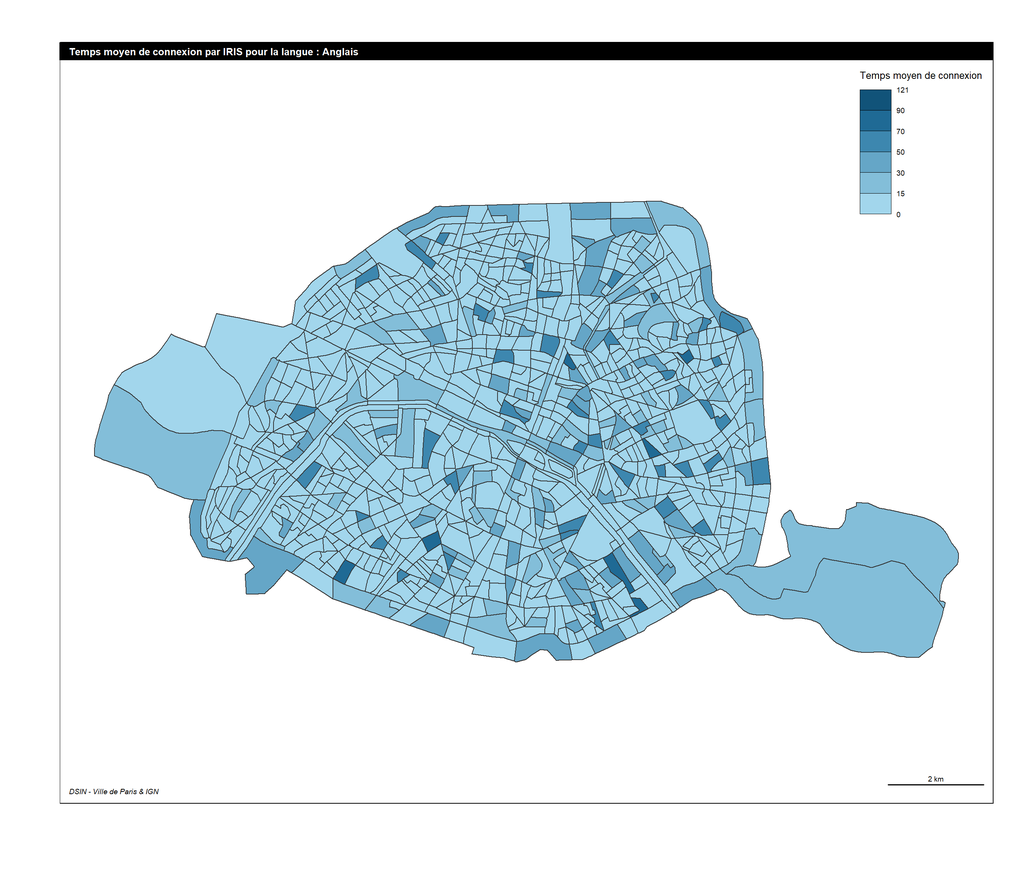

```r
choroLayer(x = carto_5.anglais,
           var = "Temps_moy",
           breaks = c(0,15,30,50,70,90,121),
           nclass = 5,
           legend.title.txt = "Temps moyen de connexion",
           legend.pos = "topright")
layoutLayer(title = "Temps moyen de connexion par IRIS pour la langue : Anglais",
            sources = "DSIN - Ville de Paris & IGN")
```

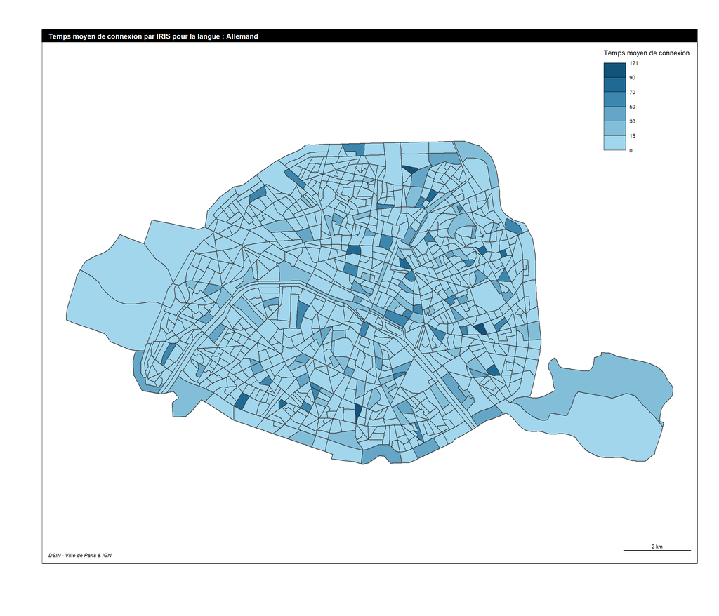

```r
choroLayer(x = carto_5.allemand,
           var = "Temps_moy",
           breaks = c(0,15,30,50,70,90,121),
           nclass = 5,
           legend.title.txt = "Temps moyen de connexion",
           legend.pos = "topright")
layoutLayer(title = "Temps moyen de connexion par IRIS pour la langue : Allemand",
            sources = "DSIN - Ville de Paris & IGN")
```

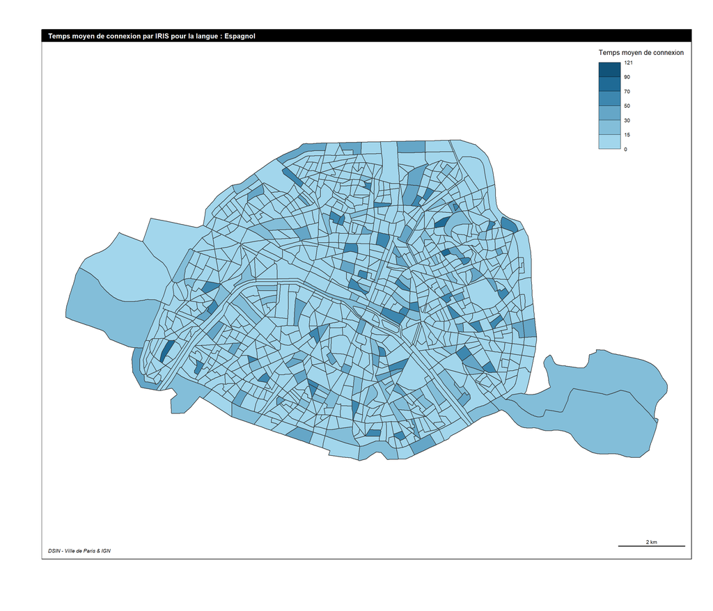

```r
choroLayer(x = carto_5.espagnol,
           var = "Temps_moy",
           breaks = c(0,15,30,50,70,90,121),
           nclass = 5,
           legend.title.txt = "Temps moyen de connexion",
           legend.pos = "topright")
layoutLayer(title = "Temps moyen de connexion par IRIS pour la langue : Espagnol",
            sources = "DSIN - Ville de Paris & IGN")
```

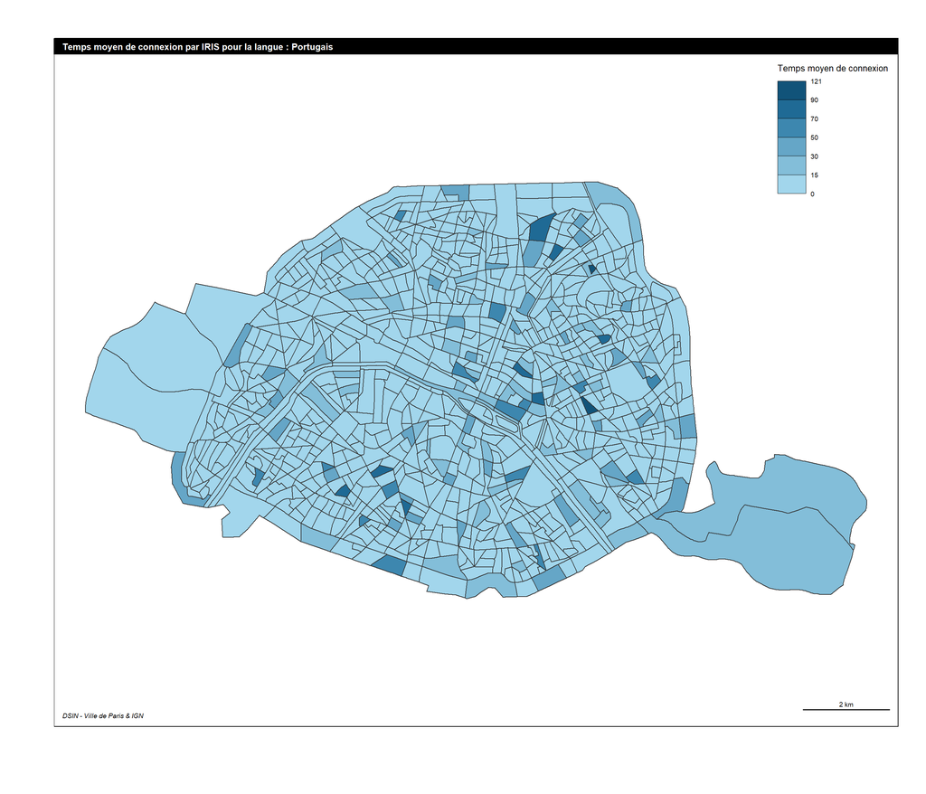

```r
choroLayer(x = carto_5.portugais,
           var = "Temps_moy",
           breaks = c(0,15,30,50,70,90,121),
           nclass = 5,
           legend.title.txt = "Temps moyen de connexion",
           legend.pos = "topright")
layoutLayer(title = "Temps moyen de connexion par IRIS pour la langue : Portugais",
            sources = "DSIN - Ville de Paris & IGN")
```

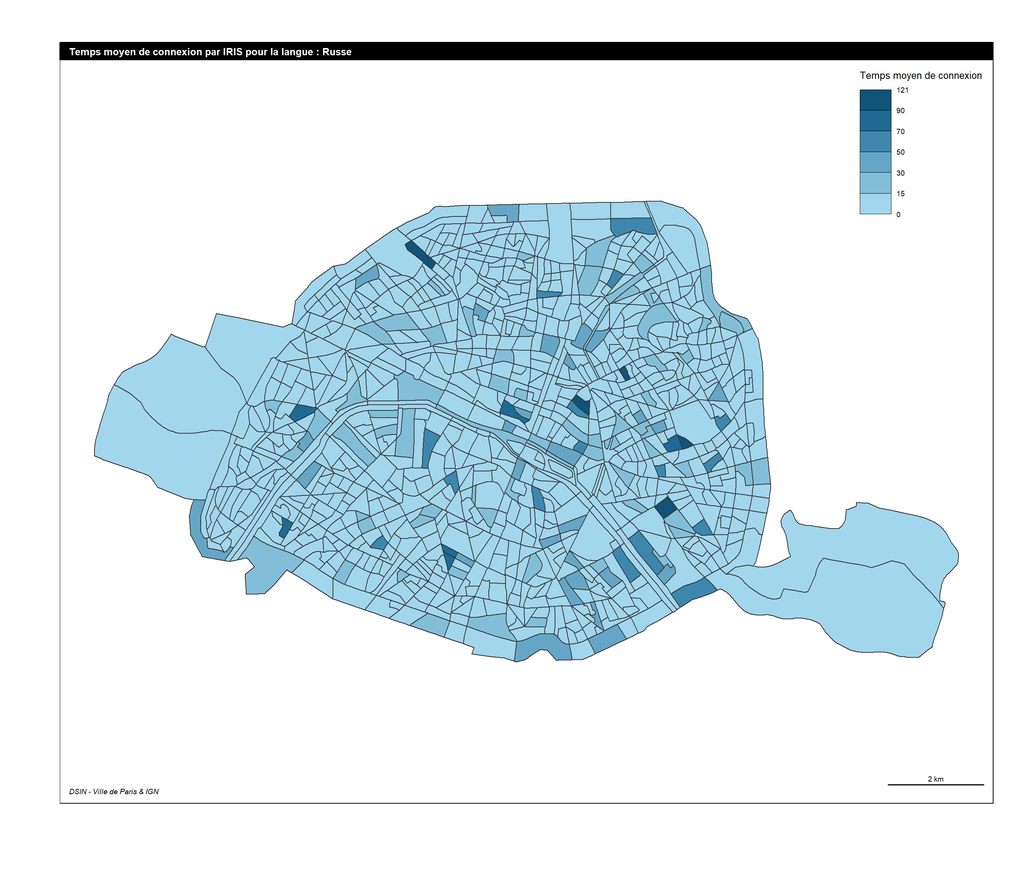

```r
choroLayer(x = carto_5.russe,
           var = "Temps_moy",
           breaks = c(0,15,30,50,70,90,121),
           nclass = 5,
           legend.title.txt = "Temps moyen de connexion",
           legend.pos = "topright")
layoutLayer(title = "Temps moyen de connexion par IRIS pour la langue : Russe",
            sources = "DSIN - Ville de Paris & IGN")
```